# Семинар 1. Первый раз в первый класс!

May 22, 2018

# 1 На плечах гигантов :)

Базовый R умеет не так много. Сила R во множестве пакетов, написанных добровольцами. Пакеты содержат вкусные и сочные функции и расширяют возможности R.

Чтобы начать использовать любой пакет, скажем, `tidyverse`, нужно сделать два действия.

- установить пакет: это действие выполняется один раз и скорее всего оно уже сделано :)
- подключить пакет: это действие выполняется каждый раз при начале работы!

Установка пакеты: в меню Rstudio `Tools` - `Install packages`.

- Пример.

Подключаем пакет `tidyverse`, `rio` и `skimr`!

```r
library(tidyverse)
library(rio)
library(skimr)
```

Пакет `tidyverse` - это коллекция из множества пакетов. Например, в `tidyverse` входят: - `dplyr` для манипуляций с данными - `ggplot2` для построения графиков - `lubridate` для работы с датами во временных рядах

А два других: - `rio` импортирует и экспортирует данные практически во все известные форматы; - `skimr` считает самые разнообразные описательные статистики, которые только можно представить.

Если при подключении пакета возникает ошибка (Error), то скорее всего пакет не установлен и его нужно установить через меню `Tools` - `Install packages`.

- Упражнение 1.

Подключите пакеты `lattice` и `DataExplorer`. Не забудьте раскомментировать строки, убрав решетку `#`.

```r
library(lattice)
library(DataExplorer)
```

Что умеют эти пакеты? - `lattice` пригодится нам для графиков - `DataExplorer` для быстрого автоматического графического анализа

- Пример. Загружаем данные из spss

Предварительно должен быть подключен пакет `rio`.

После загрузки мы сразу проверяем целостность данных командой `glimpse()`. Также разумно посмотреть на первые строки набора данных командой `head()` и на последние командой `tail()`.

```r
some <- import('manipulate.sav')
glimpse(some)
```

```
## Observations: 100
## Variables: 7
## $ ID            <dbl> 1, 2, 3, 4, 5, 6, 7, 8, 9, 10, 11, 12, 13, 14, 1...
## $ Sex           <chr> "M", "M", "M", "M", "M", "F", "M", "F", "M", "M"...
## $ FundCode      <chr> "HOS", "HOS", "HOS", "TAC", "TAC", "HOS", "HOS",...
## $ ArrivalDate   <dttm> 2005-03-10 03:04:00, 2004-08-27 12:32:00, 2005-...
## $ EmergDate     <dttm> 2005-03-10 05:09:00, 2004-08-27 13:10:00, 2005-...
## $ DischargeDate <dttm> 2005-03-16 13:00:00, 2004-08-27 14:00:00, 2005-...
## $ LengthofStay  <dbl> 6, 0, 5, 0, 10, 16, 2, 0, 5, 7, 9, 3, 1, 5, 8, 0...
```

```r
head(some)
```

```
##   ID Sex FundCode         ArrivalDate           EmergDate
## 1  1   M      HOS 2005-03-10 03:04:00 2005-03-10 05:09:00
## 2  2   M      HOS 2004-08-27 12:32:00 2004-08-27 13:10:00
## 3  3   M      HOS 2005-02-19 19:18:00 2005-02-20 03:39:00
## 4  4   M      TAC 2007-09-24 09:35:00 2007-09-24 11:38:00
## 5  5   M      TAC 2009-01-19 08:39:00 2009-01-19 22:06:00
## 6  6   F      HOS 2008-12-16 08:58:00 2008-12-17 18:59:00
##         DischargeDate LengthofStay
## 1 2005-03-16 13:00:00            6
## 2 2004-08-27 14:00:00            0
## 3 2005-02-25 01:00:00            5
## 4 2007-09-24 17:05:00            0
## 5 2009-01-29 13:01:00           10
## 6 2009-01-02 05:45:00           16
```

```r
tail(some)
```

```
##      ID Sex FundCode         ArrivalDate           EmergDate
## 95   95   M      HOS 2005-09-11 02:41:59 2005-09-11 11:05:00
## 96   96   F      DVA 2005-09-17 15:57:00 2005-09-17 16:17:00
## 97   97   M      HOS 2005-09-26 18:11:00 2005-09-26 23:54:00
## 98   98   F      TAC 2005-10-02 13:44:00 2005-10-02 22:42:00
## 99   99   M      TAC 2005-10-25 00:01:00 2005-10-25 04:16:00
## 100 100   M      HOS 2005-10-30 15:35:00 2005-10-31 11:27:59
##           DischargeDate LengthofStay
## 95  2005-09-14 10:00:00            3
## 96  2005-09-23 13:30:00            5
## 97  2005-10-03 11:38:00            6
## 98  2005-10-06 16:00:00            4
## 99  2005-10-28 12:08:00            3
## 100 2005-11-04 10:49:00            4
```

- Сколько переменных в наборе данных? *7*
- Сколько наблюдений? *100*
- Упражнение 2.

Загрузите данные `cola.dta` из stata. Посмотрите на первые и последние строки. - Сколько переменных в наборе данных? *5* - Сколько наблюдений? *5466*

```r
cola <- import('cola.dta')
glimpse(cola)
```

```
## Observations: 5,466
## Variables: 5
## $ id      <dbl> 1, 1, 1, 2, 2, 2, 3, 3, 3, 4, 4, 4, 5, 5, 5, 6, 6, 6, ...
## $ choice  <dbl> 0, 0, 1, 0, 0, 1, 0, 0, 1, 0, 0, 1, 0, 0, 1, 0, 0, 1, ...
## $ price   <dbl> 1.79, 1.79, 1.79, 1.79, 1.79, 0.89, 1.41, 0.84, 0.89, ...
## $ feature <dbl> 0, 0, 0, 0, 0, 1, 0, 0, 1, 0, 0, 1, 0, 0, 0, 1, 0, 0, ...
## $ display <dbl> 0, 0, 0, 0, 0, 1, 0, 1, 0, 0, 0, 0, 0, 0, 0, 1, 0, 0, ...
```

```r
head(cola)
```

```
##   id choice price feature display
## 1  1      0  1.79       0       0
## 2  1      0  1.79       0       0
## 3  1      1  1.79       0       0
## 4  2      0  1.79       0       0
## 5  2      0  1.79       0       0
## 6  2      1  0.89       1       1
```

```r
tail(cola)
```

```
##        id choice price feature display
## 5461 1821      0  1.39       0       0
## 5462 1821      1  0.89       0       0
## 5463 1821      0  1.39       0       0
## 5464 1822      0  1.19       1       0
## 5465 1822      0  0.88       1       1
## 5466 1822      1  0.88       1       1
```

Исключение составляет только загрузка данных `eviews`. Пакет `rio` пока что не умеет их импортировать. Приходится использовать другой пакет :)

```r
library(hexView) # подключаем специальный пакет для чтения данных eviews
housing <- readEViews('housing.wf1')
glimpse(housing)
```

```
## Observations: 546
## Variables: 12
## $ AIRCO    <dbl> 0, 0, 0, 0, 0, 1, 0, 0, 0, 1, 1, 0, 0, 0, 0, 1, 0, 0,...
## $ BATHRMS  <dbl> 1, 1, 1, 1, 1, 1, 2, 1, 1, 2, 2, 1, 1, 1, 1, 1, 1, 1,...
## $ BEDROOMS <dbl> 3, 2, 3, 3, 2, 3, 3, 3, 3, 3, 3, 2, 3, 3, 2, 2, 3, 4,...
## $ DRIVEWAY <dbl> 1, 1, 1, 1, 1, 1, 1, 1, 1, 1, 1, 0, 1, 0, 1, 1, 0, 1,...
## $ FULLBASE <dbl> 1, 0, 0, 0, 0, 1, 1, 0, 1, 0, 1, 0, 0, 0, 0, 0, 0, 0,...
## $ GARAGEPL <dbl> 1, 0, 0, 0, 0, 0, 2, 0, 0, 1, 3, 0, 0, 0, 0, 0, 1, 0,...
## $ GASHW    <dbl> 0, 0, 0, 0, 0, 0, 0, 0, 0, 0, 0, 0, 0, 0, 0, 0, 0, 0,...
## $ LOTSIZE  <dbl> 5850, 4000, 3060, 6650, 6360, 4160, 3880, 4160, 4800,...
## $ PREFAREA <dbl> 0, 0, 0, 0, 0, 0, 0, 0, 0, 0, 0, 0, 0, 0, 0, 0, 0, 0,...
## $ PRICE    <dbl> 42000, 38500, 49500, 60500, 61000, 66000, 66000, 6900...
## $ RECROOM  <dbl> 0, 0, 0, 1, 0, 1, 0, 0, 1, 1, 0, 0, 0, 0, 0, 0, 0, 0,...
## $ STORIES  <dbl> 2, 1, 1, 2, 1, 1, 2, 3, 1, 4, 1, 1, 2, 1, 1, 1, 2, 3,...
```

# 2 Первый взгляд

- Пример. Возьмём встроенный в пакет `ggplot2` набор данных про бриллианты.

```r
df <- diamonds
```

Для описательных статистик понадобится подключённый ранее пакет `skimr`.

```r
skim(df)
```

```
## Skim summary statistics
##  n obs: 53940
##  n variables: 10
##
## Variable type: factor
##  variable missing complete     n n_unique
##   clarity       0    53940 53940        8
##     color       0    53940 53940        7
##       cut       0    53940 53940        5
##                                     top_counts ordered
##   SI1: 13065, VS2: 12258, SI2: 9194, VS1: 8171    TRUE
##            G: 11292, E: 9797, F: 9542, H: 8304    TRUE
##  Ide: 21551, Pre: 13791, Ver: 12082, Goo: 4906    TRUE
##
## Variable type: integer
##  variable missing complete     n   mean      sd  p0 p25  p50     p75  p100
##     price       0    53940 53940 3932.8 3989.44 326 950 2401 5324.25 18823
##      hist
##  ▇▃▂▁▁▁▁▁
##
## Variable type: numeric
##  variable missing complete     n  mean   sd   p0   p25   p50   p75  p100
##     carat       0    53940 53940  0.8  0.47  0.2  0.4   0.7   1.04  5.01
##     depth       0    53940 53940 61.75 1.43 43   61    61.8  62.5  79
##     table       0    53940 53940 57.46 2.23 43   56    57    59    95
##         x       0    53940 53940  5.73 1.12  0    4.71  5.7   6.54 10.74
##         y       0    53940 53940  5.73 1.14  0    4.72  5.71  6.54 58.9
##         z       0    53940 53940  3.54 0.71  0    2.91  3.53  4.04 31.8
##      hist
##  ▇▅▁▁▁▁▁▁
##  ▁▁▁▃▇▁▁▁
##  ▁▅▇▁▁▁▁▁
##  ▁▁▁▇▇▃▁▁
##  ▇▁▁▁▁▁▁▁
##  ▇▃▁▁▁▁▁▁
```

Дальше будем строить гистограммы! Если нужно посмотреть по-быстрому, то можно сделать так:

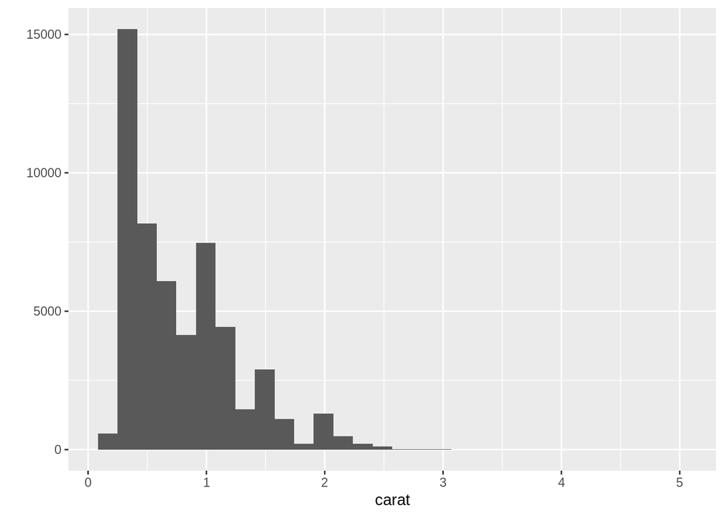

```r
qplot(data = df, x = carat)
```

Но вообще на графиках должны быть подписаны оси и название.

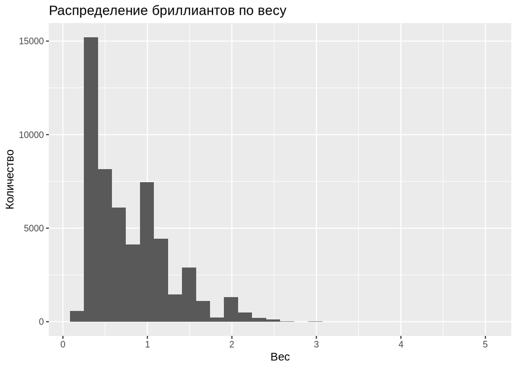

```r
qplot(data = df, x = carat) +
  labs(x = 'Вес', y = 'Количество', title = 'Распределение бриллиантов по весу')
```

Потренируемся с качественными переменными и нарисуем гистограмму для качества огранки бриллианта.

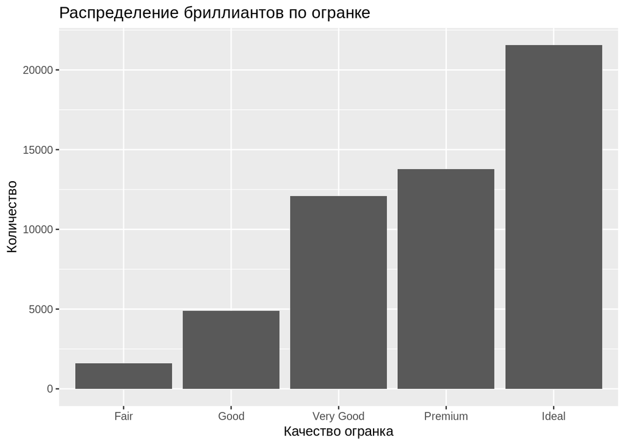

```r
qplot(data = df, x = cut)  +
  labs(x = 'Качество огранка', y = 'Количество', title = 'Распределение бриллиантов по огранке')
```

C помощью `qplot` можно создавать и диаграммы рассеяния. Посмотрим сразу на цену бриллианта и его вес.

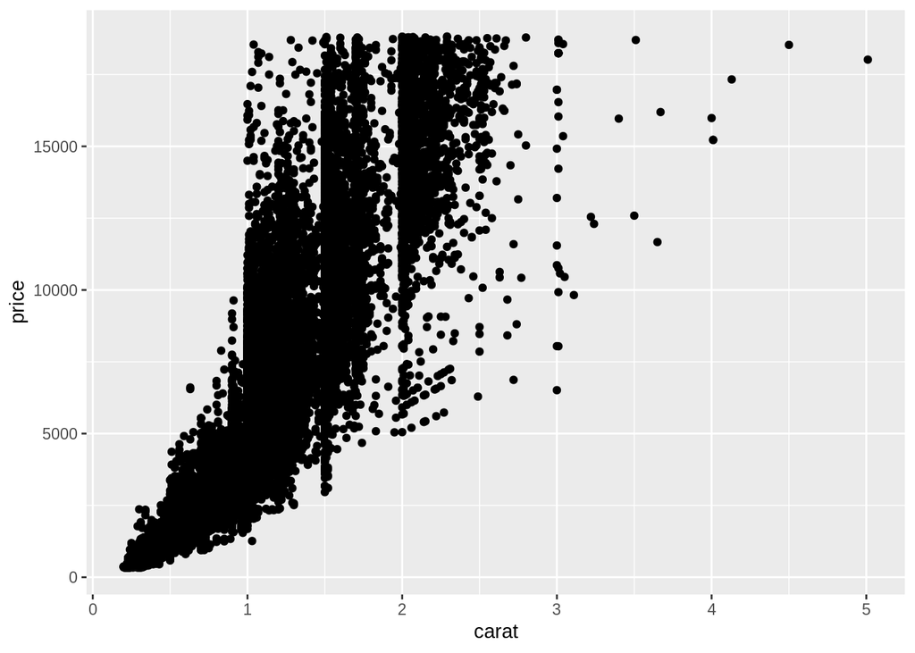

```r
qplot(data = df, x = carat, y = price)
```

А можно визуализировать сразу несколько диаграмм! Для этого, например, используется пакет `lattice` и функция `splom`.

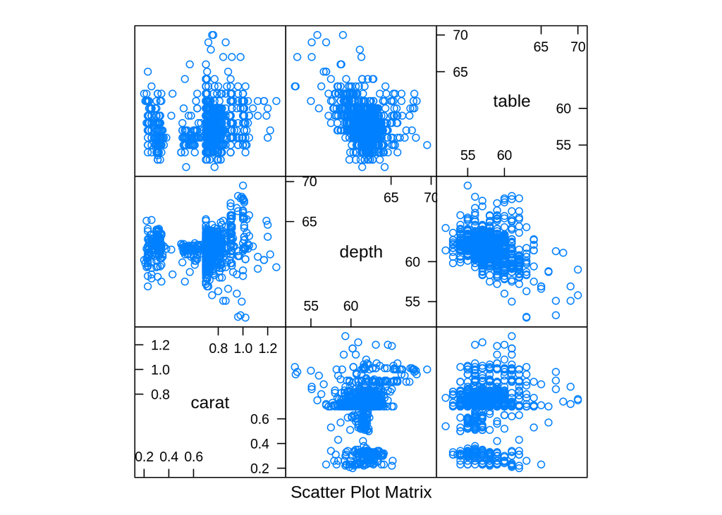

```r
library(lattice) # загружаем пакет
splom(df[1:1000, c('carat', 'depth', 'table')]) # строим диаграммы рассеяния для 1000 наблюдений
```

- Упражнение 3.

Постройте гистограмму для цены бриллианта. Она находится в столбце `price` набора данных под названием `df`. Не забудьте подписать оси и придумать название.

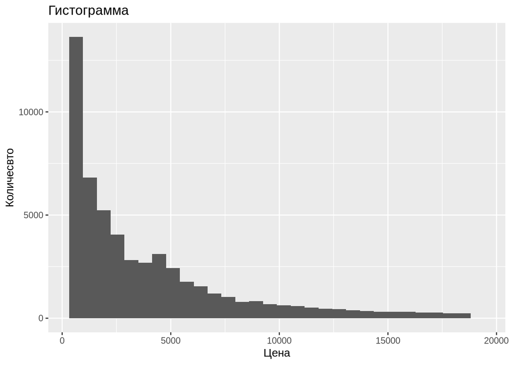

```r
qplot(data = df, x = price) +
 labs(x = 'Цена', y = 'Количесвто', title = 'Гистограмма')
```

Постройте диаграмму рассеяния: по оси абсцисс изобразите параметры бриллианта (столбец `depth`), по оси ординат — цену (`price`).

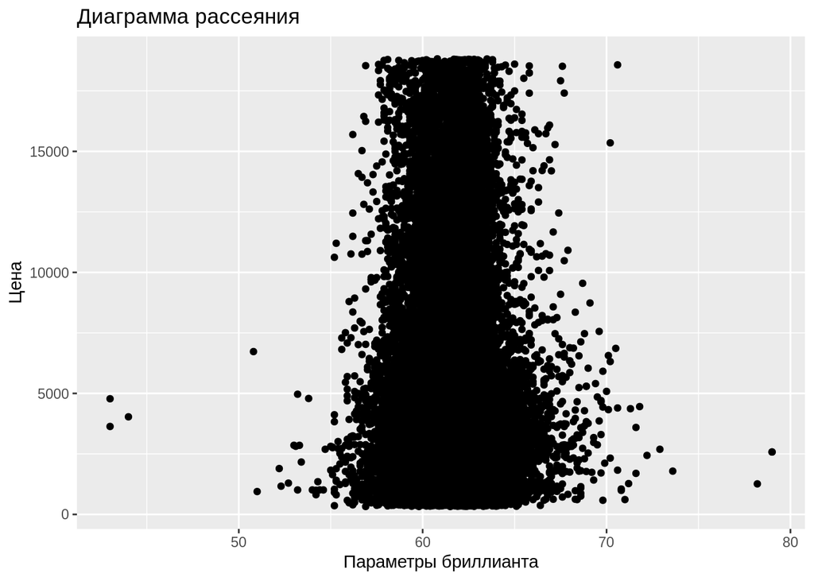

```r
qplot(data = df, x = depth, y = price) +
 labs(x = 'Параметры бриллианта', y = 'Цена', title = 'Диаграмма рассеяния')
```

# 3 Одним махом!

Есть и пакеты для автоматического графического анализа данных, например, `DataExplorer`.

- Пример.

Если до прихода гостей осталось 5 минут и нужно быстро глянуть на данные:

```r
library(DataExplorer)
create_report(diamonds)
```

```
##
##
## processing file: report.rmd
```

[output not shown]

[output not shown]

[output not shown]

[output not shown]

```
## output file: /home/boris/Documents/r_intro_2/docs/report.knit.md
```

[output not shown]

```
##
## Output created: report.html
```

```
##
##
## Report is generated at "/home/boris/Documents/r_intro_2/docs/report.html".
```

# 4 Возня с данными

Отобрать наблюдения по нескольким критериям можно с помощью команды `filter()`

- Пример.
- По каким критериям отобраны бриллианты?

```r
diamonds2 <- filter(diamonds, price > mean(price), carat < mean(carat))
skim(diamonds2)
```

```
## Skim summary statistics
##  n obs: 198
##  n variables: 10
##
## Variable type: factor
##  variable missing complete   n n_unique                         top_counts
##   clarity       0      198 198        5  VVS: 79, VVS: 48, VS1: 29, IF: 26
##     color       0      198 198        6          D: 93, E: 47, F: 47, G: 6
##       cut       0      198 198        5 Ide: 140, Ver: 39, Pre: 11, Goo: 6
##  ordered
##     TRUE
##     TRUE
##     TRUE
##
## Variable type: integer
##  variable missing complete   n   mean     sd   p0    p25    p50  p75 p100
##     price       0      198 198 4395.4 464.43 3936 4048.5 4240.5 4504 6607
##      hist
##  ▇▃▂▁▁▁▁▁
##
## Variable type: numeric
##  variable missing complete   n  mean    sd    p0   p25   p50   p75  p100
##     carat       0      198 198  0.71 0.052  0.51  0.7   0.71  0.74  0.79
##     depth       0      198 198 61.51 0.93  58.4  61.1  61.6  62    65.4
##     table       0      198 198 56.64 1.89  53    56    56    57    66
##         x       0      198 198  5.73 0.15   5.21  5.7   5.75  5.83  6.03
##         y       0      198 198  5.76 0.15   5.11  5.73  5.78  5.85  6.06
##         z       0      198 198  3.53 0.095  3.13  3.51  3.55  3.58  3.74
##      hist
##  ▁▁▁▁▁▇▃▃
##  ▁▁▃▇▅▁▁▁
##  ▂▇▃▂▁▁▁▁
##  ▁▁▁▁▅▇▅▁
##  ▁▁▁▁▁▇▅▁
##  ▁▁▁▁▂▇▃▁
```

- Упражнение 4.

Отберите бриллианты с длиной, переменная `x`, больше 5 мм. - Чему равна их средняя цена? *5455.1*

```r
diamonds3 <- filter(df, x > 5)
skim(diamonds3)
```

```
## Skim summary statistics
##  n obs: 36321
##  n variables: 10
##
## Variable type: factor
##  variable missing complete     n n_unique
##   clarity       0    36321 36321        8
##     color       0    36321 36321        7
##       cut       0    36321 36321        5
##                                   top_counts ordered
##   SI1: 9895, VS2: 8185, SI2: 8174, VS1: 5093    TRUE
##           G: 7395, F: 6390, H: 6005, E: 5895    TRUE
##  Ide: 12825, Pre: 9812, Ver: 8528, Goo: 3696    TRUE
##
## Variable type: integer
##  variable missing complete     n   mean      sd  p0  p25  p50  p75  p100
##     price       0    36321 36321 5455.1 4061.05 701 2370 4253 7108 18823
##      hist
##  ▇▆▃▂▁▁▁▁
##
## Variable type: numeric
##  variable missing complete     n  mean   sd    p0   p25   p50   p75  p100
##     carat       0    36321 36321  1.02 0.43  0.25  0.7   1     1.21  5.01
##     depth       0    36321 36321 61.76 1.55 43    61    61.9  62.6  79
##     table       0    36321 36321 57.71 2.28 43    56    57    59    95
##         x       0    36321 36321  6.33 0.85  5.01  5.68  6.34  6.83 10.74
##         y       0    36321 36321  6.33 0.9   4.11  5.7   6.34  6.82 58.9
##         z       0    36321 36321  3.91 0.55  0     3.52  3.92  4.21 31.8
##      hist
##  ▇▇▂▁▁▁▁▁
##  ▁▁▁▃▇▁▁▁
##  ▁▃▇▁▁▁▁▁
##  ▇▇▇▃▂▁▁▁
##  ▇▁▁▁▁▁▁▁
##  ▇▆▁▁▁▁▁▁
```

Перейдём к созданию новых переменных!

- Пример.

Мы добавим в набор данных логарифм цены каждого бриллианта. - Под каким названием добавлена переменная в набор данных? *lprice*

```r
diamonds4 <- mutate(diamonds, lprice = log(price))
skim(diamonds4)
```

```
## Skim summary statistics
##  n obs: 53940
##  n variables: 11
##
## Variable type: factor
##  variable missing complete     n n_unique
##   clarity       0    53940 53940        8
##     color       0    53940 53940        7
##       cut       0    53940 53940        5
##                                     top_counts ordered
##   SI1: 13065, VS2: 12258, SI2: 9194, VS1: 8171    TRUE
##            G: 11292, E: 9797, F: 9542, H: 8304    TRUE
##  Ide: 21551, Pre: 13791, Ver: 12082, Goo: 4906    TRUE
##
## Variable type: integer
##  variable missing complete     n   mean      sd  p0 p25  p50     p75  p100
##     price       0    53940 53940 3932.8 3989.44 326 950 2401 5324.25 18823
##      hist
##  ▇▃▂▁▁▁▁▁
##
## Variable type: numeric
##  variable missing complete     n  mean   sd    p0   p25   p50   p75  p100
##     carat       0    53940 53940  0.8  0.47  0.2   0.4   0.7   1.04  5.01
##     depth       0    53940 53940 61.75 1.43 43    61    61.8  62.5  79
##    lprice       0    53940 53940  7.79 1.01  5.79  6.86  7.78  8.58  9.84
##     table       0    53940 53940 57.46 2.23 43    56    57    59    95
##         x       0    53940 53940  5.73 1.12  0     4.71  5.7   6.54 10.74
##         y       0    53940 53940  5.73 1.14  0     4.72  5.71  6.54 58.9
##         z       0    53940 53940  3.54 0.71  0     2.91  3.53  4.04 31.8
##      hist
##  ▇▅▁▁▁▁▁▁
##  ▁▁▁▃▇▁▁▁
##  ▂▇▆▆▆▇▅▃
##  ▁▅▇▁▁▁▁▁
##  ▁▁▁▇▇▃▁▁
##  ▇▁▁▁▁▁▁▁
##  ▇▃▁▁▁▁▁▁
```

- Упражнение 5.

```r
diamonds5 <- mutate(diamonds, carat_price = price/carat)
skim(diamonds5)
```

```
## Skim summary statistics
##  n obs: 53940
##  n variables: 11
##
## Variable type: factor
##  variable missing complete     n n_unique
##   clarity       0    53940 53940        8
##     color       0    53940 53940        7
##       cut       0    53940 53940        5
##                                     top_counts ordered
##   SI1: 13065, VS2: 12258, SI2: 9194, VS1: 8171    TRUE
##            G: 11292, E: 9797, F: 9542, H: 8304    TRUE
##  Ide: 21551, Pre: 13791, Ver: 12082, Goo: 4906    TRUE
##
## Variable type: integer
##  variable missing complete     n   mean      sd  p0 p25  p50     p75  p100
##     price       0    53940 53940 3932.8 3989.44 326 950 2401 5324.25 18823
##      hist
##  ▇▃▂▁▁▁▁▁
##
## Variable type: numeric
##     variable missing complete     n    mean      sd      p0     p25
##        carat       0    53940 53940    0.8     0.47    0.2     0.4
##  carat_price       0    53940 53940 4008.39 2012.67 1051.16 2477.94
##        depth       0    53940 53940   61.75    1.43   43      61
##        table       0    53940 53940   57.46    2.23   43      56
##            x       0    53940 53940    5.73    1.12    0       4.71
##            y       0    53940 53940    5.73    1.14    0       4.72
##            z       0    53940 53940    3.54    0.71    0       2.91
##      p50     p75     p100     hist
##     0.7     1.04     5.01 ▇▅▁▁▁▁▁▁
##  3495.2  4949.6  17828.85 ▇▇▂▁▁▁▁▁
##    61.8    62.5     79    ▁▁▁▃▇▁▁▁
##    57      59       95    ▁▅▇▁▁▁▁▁
##     5.7     6.54    10.74 ▁▁▁▇▇▃▁▁
##     5.71    6.54    58.9  ▇▁▁▁▁▁▁▁
##     3.53    4.04    31.8  ▇▃▁▁▁▁▁▁
```

Табличку с данными иногда приходится сортировать!

- Пример.

Мы последовательно выполним два действия, сортировку и отбор самых верхних строк.

```r
diamonds6 <- arrange(diamonds, price) %>% head(3)
diamonds6
```

```
## # A tibble: 3 x 10
##   carat cut     color clarity depth table price     x     y     z
##   <dbl> <ord>   <ord> <ord>   <dbl> <dbl> <int> <dbl> <dbl> <dbl>
## 1  0.23 Ideal   E     SI2      61.5    55   326  3.95  3.98  2.43
## 2  0.21 Premium E     SI1      59.8    61   326  3.89  3.84  2.31
## 3  0.23 Good    E     VS1      56.9    65   327  4.05  4.07  2.31
```

- Упражнение 6.

Отсортируйте бриллианты по массе и отберите самые нижние пять строк.

```r
diamonds7 <- arrange(df, carat) %>% tail(5)
diamonds7
```

```
## # A tibble: 5 x 10
##   carat cut     color clarity depth table price     x     y     z
##   <dbl> <ord>   <ord> <ord>   <dbl> <dbl> <int> <dbl> <dbl> <dbl>
## 1  4.01 Premium I     I1       61      61 15223  10.1 10.1   6.17
## 2  4.01 Premium J     I1       62.5    62 15223  10.0  9.94  6.24
## 3  4.13 Fair    H     I1       64.8    61 17329  10    9.85  6.43
## 4  4.5  Fair    J     I1       65.8    58 18531  10.2 10.2   6.72
## 5  5.01 Fair    J     I1       65.5    59 18018  10.7 10.5   6.98
```

# 5 Россия - родина слонов!

С данными на русском языке иногда приходится повозиться: пакет `rio` может не справляться с импортом русским букв.

Сейчас распространено две кодировки для русского текста: UTF-8 и CP1251. Более современной является UTF-8 и сохранять свои файлы разумно именно в ней. Однако приходится работать и с CP1251.

Перед нами два `csv` файла с русскими буквами `rus_utf8.csv` и `rus_cp1251.csv`.

- Упражнение 7.

Проверьте, читаются ли эти файлы командой `import()`

```r
data_utf <- import('rus_utf8.csv')
glimpse(data_utf)
```

```
## Observations: 3
## Variables: 3
## $ one   <chr> "привет", "дорогой", "друг"
## $ two   <int> 5, 5, 5
## $ three <int> 6, 7, 9
```

```r
data_cp <- import('rus_cp1251.csv')
glimpse(data_cp)
```

```
## Observations: 3
## Variables: 3
## $ one   <chr> "\xef\xf0\xe8\xe2\xe5\xf2", "\xe4\xee\xf0\xee\xe3\xee\xe...
## $ two   <int> 5, 5, 5
## $ three <int> 6, 7, 9
```

- В каком случае русские буквы читаются без кракозябр?

Здесь на помощь приходят другие пакеты, например, функция `read_csv` из пакета `readr`:

```r
data_cp2 <- read_csv('rus_cp1251.csv', locale = locale(encoding = 'CP1251'))
glimpse(data_cp2)
```

```
## Observations: 3
## Variables: 3
## $ one   <chr> "привет", "дорогой", "друг"
## $ two   <int> 5, 5, 5
## $ three <int> 6, 7, 9
```

```r
data_utf2 <- read_csv('rus_utf8.csv', locale = locale(encoding = 'UTF8'))
glimpse(data_utf2)
```

```
## Observations: 3
## Variables: 3
## $ one   <chr> "привет", "дорогой", "друг"
## $ two   <int> 5, 5, 5
## $ three <int> 6, 7, 9
```

# 6 Не пропадёт наш скорбный труд :)

Есть много форматов данных. Самым простым и потому универсальным является формат `csv`, comma separated values. Этот формат понимают все программы, работающие с данными.

- Пример.

Экспортируем набор данных про бриллианты в `csv`:

```r
export(diamonds, 'diamonds.csv')
```

Теперь эти данные можно прочитать в большинстве программ! Ровно таким же образом можно экспортировать и в другие форматы: - `xlsx` для MS Excel - `dta` для stata - `sav` для spss

- Упражнение 8.

Экспортируйте набор данных `diamonds` в эксельчик.

```r
export(df, 'diamonds.xlsx')
```

Не забудьте, что имя файла должно быть в кавычках. Двойных или одинарных - не важно.

# 7 Спасите-помогите

- Если хочется прочитать подробнее про конкретную функцию, например, про `filter`:

```r
?filter
```

- Если хочется посмотреть, какие функции живут в пакете, например, в `skimr`:

```r
help(package = 'skimr')
```

- Иногда помимо занудного описания каждой функции пакет содержит ‘виньетки’. Виньетка - это пример использования пакета в бою. Виньетка не обязана описывать каждую функцию пакета, зато может содержать гораздо больше пояснений.

Можно посмотреть, какие виньетки содержит пакет,

```r
vignette(package = 'skimr')
```

А дальше, узнав название виньеток, прочитать любую из них, например,

```r
vignette('Using_skimr')
```

- Если хочется посмотреть, какие пакеты используют люди моей специальности, то можно зайти на [cran task view](https://cran.r-project.org/web/views/)
- Если хочется задать вопрос по статистике или поискать похожий, то поможет форум [stats.se](https://stats.stackexchange.com/)
- А здесь мы приготовили [подборку русскоязычных ресурсов по R](https://github.com/bdemeshev/r_links)

# 8 Как обойтись без этого курса и платных программ? :)

Открытые и бесплатные программы для работы с данными, в которых можно кликать мышкой!

- [gretl](http://gretl.sourceforge.net/). Эконометрика. Достойный конкурент для stata и eviews.
- [jasp](https://jasp-stats.org/). Альтернатива spss. Байесовский подход сразу!
- [radiant](https://radiant-rstats.github.io/docs/). Довесок к R, позволяющий работать мышкой и превратить результат в набор команд R.
- [OpenRefine](http://openrefine.org/). Мощная чистка данных.

Ура :)